# DALEX cross-comparison of of model developed in R, Java and Python

Szymon Maksymiuk, Jakub Wiśniewski

First created in Apr 25, 2019. Updated on Jan 2, 2021

# 1 Introduction

Machine learning models are being developed in different tools and different languages. On one hand it is great as everyone can choose tool that suits his needs, but on another hand it is hard to compare such models in a different way that simply by comparing accuracy scores.

In this vignette we will show how `DALEX` can be used for comparison of models across different languages.

We trained four models, `gbm` and `CatBoost` in R, `h2o` implementation of in java and `scikit-learn` implementation of gbm in Python. Then we visually explore their similarities and differences through DALEX explainers.

# 2 Data

We use `titanic` dataset. It is divided into `titanic_test` and `titanic_train` and stored in csv files. For this dataset we will train binary classifiers that predicts probability of survival from Titanic disaster.

```r
kable(titanic_test_X %>% head(), "html") %>%
  kable_styling("striped") %>%
  scroll_box(width = "100%")
```

| gender.female | gender.male | age | class.1st | class.2nd | class.3rd | class.deck.crew | class.engineering.crew | class.restaurant.staff | class.victualling.crew | embarked.Belfast | embarked.Cherbourg | embarked.Queenstown | embarked.Southampton | fare | sibsp | parch |
| --- | --- | --- | --- | --- | --- | --- | --- | --- | --- | --- | --- | --- | --- | --- | --- | --- |
| 1 | 0 | 16 | 0 | 0 | 1 | 0 | 0 | 0 | 0 | 0 | 0 | 0 | 1 | 7.1300 | 0 | 0 |
| 0 | 1 | 25 | 0 | 0 | 1 | 0 | 0 | 0 | 0 | 0 | 0 | 0 | 1 | 7.1300 | 0 | 0 |
| 1 | 0 | 28 | 0 | 1 | 0 | 0 | 0 | 0 | 0 | 0 | 1 | 0 | 0 | 24.0000 | 1 | 0 |
| 0 | 1 | 20 | 0 | 0 | 1 | 0 | 0 | 0 | 0 | 0 | 0 | 0 | 1 | 7.1806 | 0 | 0 |
| 0 | 1 | 30 | 0 | 0 | 1 | 0 | 0 | 0 | 0 | 0 | 0 | 0 | 1 | 7.0500 | 0 | 0 |
| 1 | 0 | 19 | 0 | 0 | 1 | 0 | 0 | 0 | 0 | 0 | 0 | 0 | 1 | 7.1701 | 1 | 0 |

```r
kable(titanic_train_X %>% head(), "html") %>%
  kable_styling("striped") %>%
  scroll_box(width = "100%")
```

| gender.female | gender.male | age | class.1st | class.2nd | class.3rd | class.deck.crew | class.engineering.crew | class.restaurant.staff | class.victualling.crew | embarked.Belfast | embarked.Cherbourg | embarked.Queenstown | embarked.Southampton | fare | sibsp | parch |
| --- | --- | --- | --- | --- | --- | --- | --- | --- | --- | --- | --- | --- | --- | --- | --- | --- |
| 0 | 1 | 42 | 0 | 0 | 1 | 0 | 0 | 0 | 0 | 0 | 0 | 0 | 1 | 7.1100 | 0 | 0 |
| 0 | 1 | 13 | 0 | 0 | 1 | 0 | 0 | 0 | 0 | 0 | 0 | 0 | 1 | 20.0500 | 0 | 2 |
| 0 | 1 | 16 | 0 | 0 | 1 | 0 | 0 | 0 | 0 | 0 | 0 | 0 | 1 | 20.0500 | 1 | 1 |
| 1 | 0 | 39 | 0 | 0 | 1 | 0 | 0 | 0 | 0 | 0 | 0 | 0 | 1 | 20.0500 | 1 | 1 |
| 0 | 1 | 30 | 0 | 1 | 0 | 0 | 0 | 0 | 0 | 0 | 1 | 0 | 0 | 24.0000 | 1 | 0 |
| 0 | 1 | 27 | 0 | 0 | 1 | 0 | 0 | 0 | 0 | 0 | 1 | 0 | 0 | 18.1509 | 0 | 0 |

# 3 Models in different languages

## 3.1 gbm in R

First, we train R implementation of `gbm` which we will acces thorugh `mlr` package as a wrapper. Specifying most of parameters helps us fighting similar models across languages, at least in theory.

```r
library("mlr")
set.seed(123, "L'Ecuyer")
task <- makeClassifTask(
            id = "R",
            data = cbind(titanic_train_X, titanic_train_Y),
            target = "survived"
          )
learner <- makeLearner(
            "classif.gbm",
            par.vals = list(
              distribution = "bernoulli",
              n.trees = 5000,
              interaction.depth = 4,
              n.minobsinnode = 12,
              shrinkage = 0.001,
              bag.fraction = 0.5,
              train.fraction = 1
            ),
            predict.type = "prob"
          )
r_gbm <- train(learner, task)
performance(predict(r_gbm,
                    newdata = cbind(titanic_test_X, titanic_test_Y)),
            measures = auc)
```

```
##      auc
## 0.826275
```

## 3.2 CatBoost in R

`CatBoost` is a machine learning algorithm that uses gradient boosting on decision trees. It is similiar in spirit to `gbm` and we will see how similar are trained models.

```r
library("catboost")
pool_train <- catboost.load_pool(titanic_train_X, titanic_train_Y$survived)
pool_test  <- catboost.load_pool(titanic_test_X)
r_catboost <- catboost.train(pool_train,
               test_pool = NULL,
               params = list(
                 custom_loss = "AUC",
                 iterations = 5000,
                 depth = 4,
                 logging_level = "Silent"
               ))
preds <- catboost.predict(r_catboost, pool_test, prediction_type = "Probability")
```

```r
mltools::auc_roc(preds, y)
```

```
## [1] 0.8146678
```

## 3.3 gbm in h2o (java)

We will access H2O models via `h2o` R package. Using [h2o documentation](http://docs.h2o.ai/h2o/latest-stable/h2o-docs/data-science/gbm.html) we are able to match as many parameters as it possible which will help objectively compare models.

```r
set.seed(123, "L'Ecuyer")
java_h2o_gbm <- h2o.gbm(
                  training_frame = titanic_h2o,
                  y = "survived",
                  distribution = "bernoulli",
                  ntrees = 5000,
                  max_depth = 4,
                  min_rows =  12,
                  learn_rate = 0.001
                )
h2o.auc(h2o.performance(java_h2o_gbm, newdata = titanic_test_h2o))
```

```
## [1] 0.8146509
```

## 3.4 gbm in scikit-learn (python)

Inspection of models that have been created at Python via R is not as hard as it may seem to. It is possible thanks to two packages. `reticulate` available at R and `pickle` from Python.

```python
from pandas import DataFrame, read_csv
import pandas as pd
import pickle
import sklearn.ensemble
from sklearn.metrics import auc, accuracy_score, confusion_matrix, mean_squared_error

titanic_train_X = pd.read_csv("titanic_train.csv").drop("survived", axis=1)
titanic_train_Y = pd.read_csv("titanic_train.csv").survived

model = sklearn.ensemble.GradientBoostingClassifier(
  n_estimators= 5000,
  learning_rate=0.001,
  max_depth=4,
  min_samples_split = 12
)
model = model.fit(titanic_train_X, titanic_train_Y)
pickle.dump(model, open("gbm.pkl", "wb"))
```

```r
library("reticulate")

# if needed install
# py_install("pandas")
# py_install("scikit-learn")

python_scikitlearn_gbm <- py_load_object("gbm.pkl", pickle = "pickle")
preds <- python_scikitlearn_gbm$predict_proba(titanic_test_X)[, 2]
mltools::auc_roc(preds, y)
```

```
## [1] 0.8244396
```

# 4 Model cross-language comparison

Because all four packages return slightly different objects, we have to create DALEX wrappers around them. For 3 of them we will use `DALEXtra` package, and for`catboost` we will use custom predict function.

```r
# catboost wrapper
catboost_predict <- function(object, newdata) {
  newdata_pool <- catboost.load_pool(newdata)
  return( catboost.predict(object, newdata_pool, prediction_type = "Probability"))
}
```

Now we can create DALEX wrappers around our models.

```r
library("DALEX")
library("DALEXtra")
r_explain <- DALEXtra::explain_mlr(r_gbm,
                            data = titanic_test_X,
                            y = y,
                            label = "gmb (R)",
                            type = "classification",
                            verbose = FALSE)
catboost_explain <- DALEX::explain(r_catboost,
                                   data = titanic_test_X,
                                   y = y,
                                   label = "CatBoost (R)",
                                   predict_function = catboost_predict,
                                   type = "classification",
                                   verbose = FALSE)
h2o_explain <- DALEXtra::explain_h2o(java_h2o_gbm,
                              data = titanic_test_X,
                              y = y,
                              label = "gbm (h2o/java)",
                              type = "classification",
                              verbose = FALSE)
py_explain <- DALEXtra::explain_scikitlearn("gbm.pkl",
                      data = titanic_test_X,
                      y = y,
                      label = "gbm (python/sklearn)",
                      type = "classification",
                      verbose = FALSE)
```

## 4.1 Model performance

With explainers ready, we can compare our models in order to find possible differences. Models performance and residual distribution gets our first look.

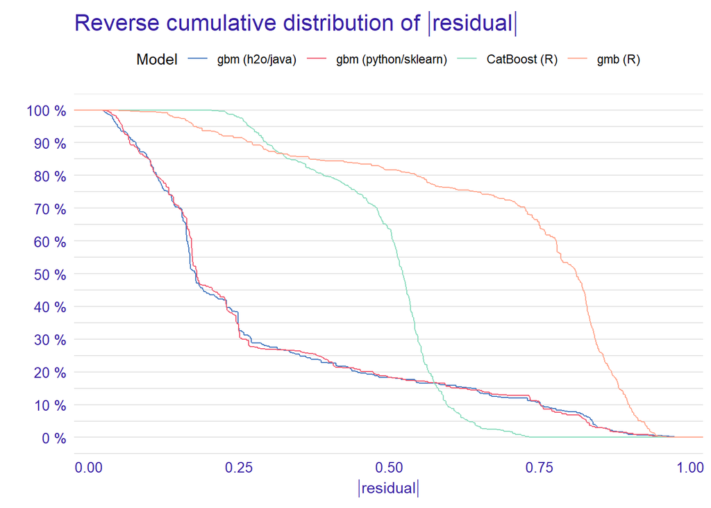

```r
plot(
  model_performance(r_explain),
  model_performance(h2o_explain),
  model_performance(py_explain),
  model_performance(catboost_explain)
  )
```

As we can see, models some models differ from each other altough the *java* and *python* models are quite similar.

## 4.2 Variable importance

Here the drop in `1 - AUC` is used to compare variable performance. Keep in mind that when defining `custom_loss_function` you have to provide arguments in correct order. Real values of `y` first and predicted second.

```r
custom_loss_function <- function(y, yhat) {
  1 - mltools::auc_roc(yhat, y)
}

mp1 <- model_parts(r_explain, type = "difference", loss_function = custom_loss_function)
mp2 <- model_parts(h2o_explain, type = "difference", loss_function = custom_loss_function)
mp3 <- model_parts(py_explain, type = "difference", loss_function = custom_loss_function)
mp4 <- model_parts(catboost_explain, type = "difference", loss_function = custom_loss_function)
```

Let’s see what features are important in in 2 selected models - created using `h2o` and `sklearn`.

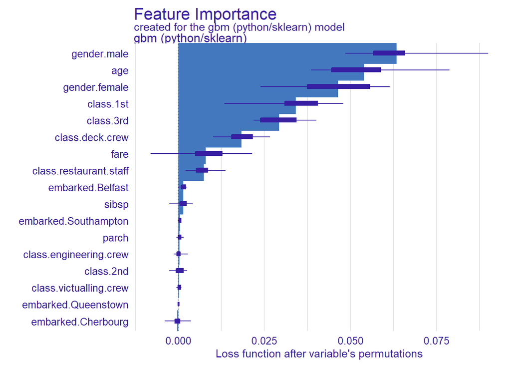

```r
plot(mp3)
```

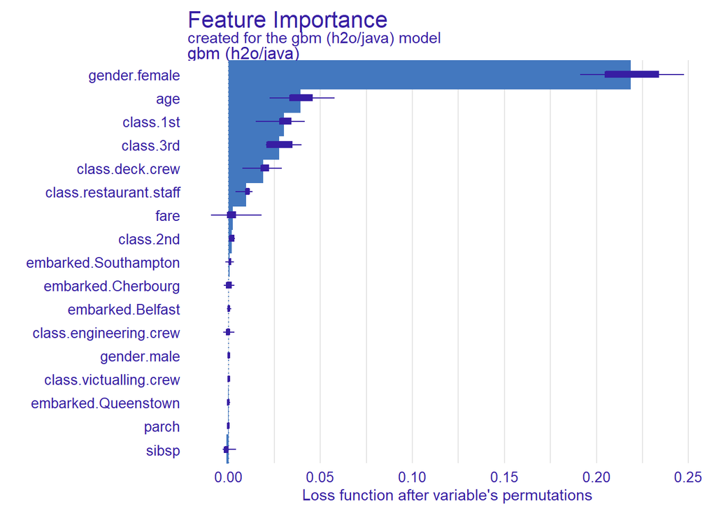

```r
plot(mp2)
```

We can see significant difference. `h2o` model figured out correlation between `gender.male` and `gender.female` and dropped one of them. `sklearn` (and other models too) use both of those columns. What is interesting, next four most significant variables are the same.

## 4.3 PDP plots for fare

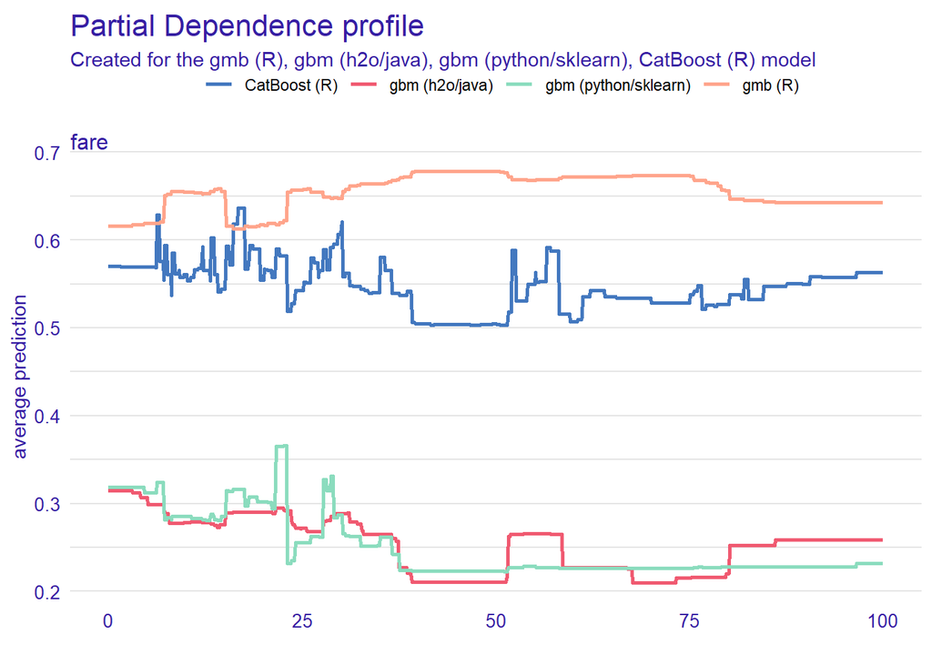

```r
pdp_r   <- model_profile(r_explain,
                          variable_splits = list(fare = seq(0,100,0.1)))
pdp_h2o  <- model_profile(h2o_explain,
                          variable_splits = list(fare = seq(0,100,0.1)))
pdp_py <- model_profile(py_explain,
                         variable_splits = list(fare = seq(0,100,0.1)))
pdp_catboost <- model_profile(catboost_explain,
                         variable_splits = list(fare = seq(0,100,0.1)))
plot(pdp_r, pdp_h2o, pdp_py, pdp_catboost)
```

We can see the difference in how our models behave for different values of `fare`.

## 4.4 PDP plots for age

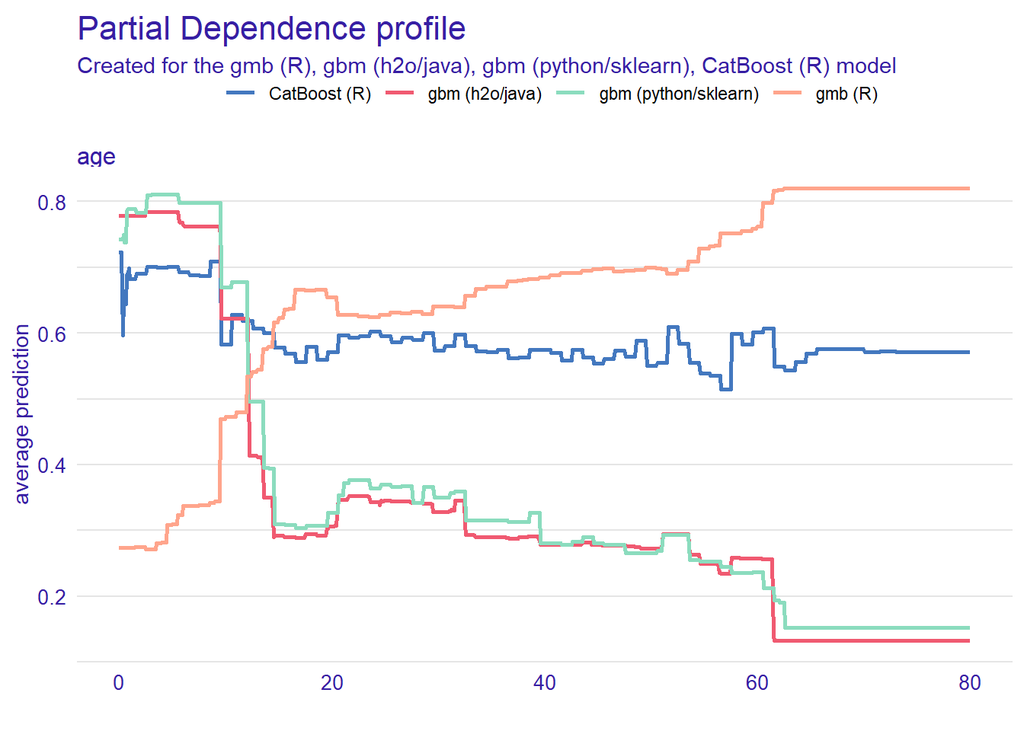

```r
pdp_r   <- model_profile(r_explain,
                          variable_splits = list(age = seq(0,80,0.1)))
pdp_h2o  <- model_profile(h2o_explain,
                          variable_splits = list(age = seq(0,80,0.1)))
pdp_py <- model_profile(py_explain,
                         variable_splits = list(age = seq(0,80,0.1)))
pdp_catboost <- model_profile(catboost_explain,
                         variable_splits = list(age = seq(0,80,0.1)))
plot(pdp_r, pdp_h2o, pdp_py, pdp_catboost)
```